# R Assignments

## Assignment 2 (Linear Regression and Hypothesis Tests)

For this exercise we will analyze the sbp dataset (file sbp1.csv). This file contains the following data of 32 subjects: systolic blood pressure (sbp, in mmHg), body mass index (bmi = weight / height2, weight in kg, height in m), age (age, in years) and smoking status (smk).

**a)** Test whether the relationship between blood pressure and body mass index differs between smokers and non-smokers. Make sure that non-smokers is the reference category. Use lm function. Interpret model fit and coefficients, inspect assumptions. Discuss how this **linear regression** is different/similar to a t-test.

```r
data2 <- read.table("/Users/apple/Downloads/sbp1.csv", header = TRUE, sep=";", dec=",")
knitr::kable(head(data2))
```

| pat_ID | sbp | bmi | age | smk |
| --- | --- | --- | --- | --- |
| 1 | 135 | 28.76 | 45 | no |
| 2 | 122 | 32.51 | 41 | no |
| 3 | 130 | 31.00 | 49 | no |
| 4 | 148 | 37.68 | 52 | no |
| 5 | 146 | 29.79 | 54 | yes |
| 6 | 129 | 27.90 | 47 | yes |

```r
oldvalues <- c("no", "yes")
newvalues <- factor(c(0,1))
data2$smkDummy <- newvalues[match(data2$smk, oldvalues)]
summary(lm(sbp~smk+bmi, data=data2))
```

```
##
## Call:
## lm(formula = sbp ~ smk + bmi, data = data2)
##
## Residuals:
##      Min       1Q   Median       3Q      Max
## -23.6172  -4.8496   0.3664   6.5083  19.1832
##
## Coefficients:
##             Estimate Std. Error t value Pr(>|t|)
## (Intercept)   63.876     11.468   5.570 5.21e-06 ***
## smkyes         8.571      3.167   2.707   0.0113 *
## bmi            2.212      0.323   6.847 1.61e-07 ***
## ---
## Signif. codes:  0 '***' 0.001 '**' 0.01 '*' 0.05 '.' 0.1 ' ' 1
##
## Residual standard error: 8.916 on 29 degrees of freedom
## Multiple R-squared:  0.6412, Adjusted R-squared:  0.6165
## F-statistic: 25.91 on 2 and 29 DF,  p-value: 3.51e-07
```

```r
fitmodel1 <- lm(sbp~smk+bmi, data=data2)
```

**Assumptions**

**-** No systematic tendencies

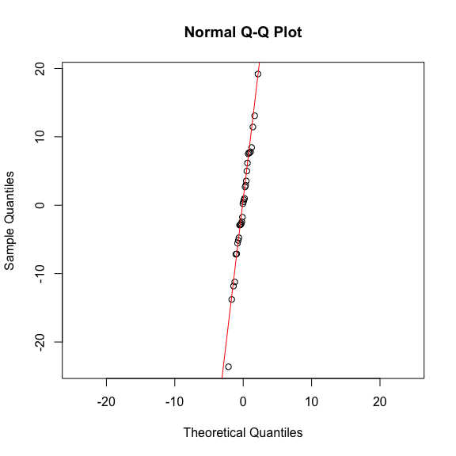

```r
qqnorm(resid(fitmodel1), asp=1); qqline(resid(fitmodel1), col="red")
```

**-** Homoscedasticity and Linearity

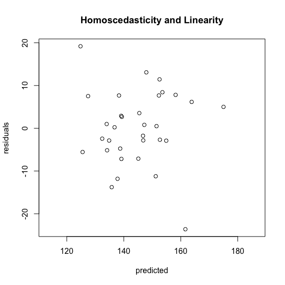

```r
plot(predict(fitmodel1), resid(fitmodel1), main = "Homoscedasticity and Linearity", ylab = "residuals", xlab="predicted", asp=1.5)
```

As shown in the figure above, the plot of the residuals again the predicted values of the model is centered around an horizontal line which indicates that the model complies with the assumption of linearity. Additionally there is no pattern between between the size of the predicted values and the residuals, which indicates that the model is not heteroscedastic.

**-** Independence of errors

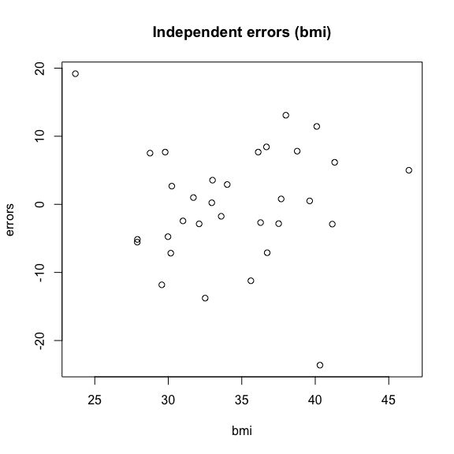

```r
plot(data2$bmi, resid(fitmodel1),  xlab = "bmi", main = "Independent errors (bmi)", ylab = "errors")
```

As the residuals of the model show no indication of a correlation or a clear pattern with the independent variable accounting for bmi, we can assume that there is no dependence of errors between the residuals and the bmi.

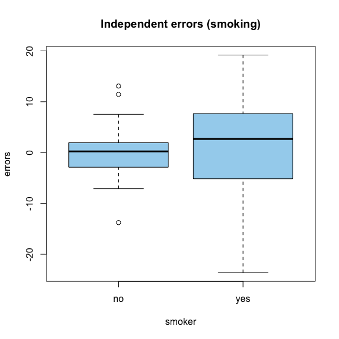

```r
plot(data2$smk, resid(fitmodel1),  xlab = "smoker", main = "Independent errors (smoking)", ylab = "errors", col="lightskyblue2")
```

Contrary to the case of bmi, it appears that the relation between the variable accounting for an individual???s smoking status and the residuals of the model has a different variance depending on the latter???s category. More specifically, the variance of the residuals in the model if relatively larger for individuals who smoke, compared to individuals who don???t. Given this, and taking into account the presence of outliers in the category of non-smokers, the assumption independence of errors is does not appear to meet when analysing the relation between the independent variable of smoking status and the residuals of the model.

Difference between linear regression and the t-test:

While the linear regression can assess the relationship between any number of predictors and and a dependent variable, the t-test looks at differences between one explanatory variable within two previously defined categories. The t-test is useful when computing differences in terms of one variable between two groups, and the regression model can actually look at the strength and the significance that effect of one or several variables have on another variable. In other words, and taking as an example the regression model here, while the t-test can look at the difference in SBP or BMI between the category of smokers and non-smokers and its statistical significance, it cannot assess the effect that neither of them have when controlling for the other.

**b)** Repeat the analysis at point a. but use age as a predictor instead of body mass index.

```r
fitmodel2 <- lm(sbp~smk+age, data=data2)
summary(fitmodel2)
```

```
##
## Call:
## lm(formula = sbp ~ smk + age, data = data2)
##
## Residuals:
##     Min      1Q  Median      3Q     Max
## -10.639  -5.518  -1.637   4.900  19.616
##
## Coefficients:
##             Estimate Std. Error t value Pr(>|t|)
## (Intercept)  48.0496    11.1296   4.317 0.000168 ***
## smkyes       10.2944     2.7681   3.719 0.000853 ***
## age           1.7092     0.2018   8.471 2.47e-09 ***
## ---
## Signif. codes:  0 '***' 0.001 '**' 0.01 '*' 0.05 '.' 0.1 ' ' 1
##
## Residual standard error: 7.738 on 29 degrees of freedom
## Multiple R-squared:  0.7298, Adjusted R-squared:  0.7112
## F-statistic: 39.16 on 2 and 29 DF,  p-value: 5.746e-09
```

**Assumptions**

**-** Normality

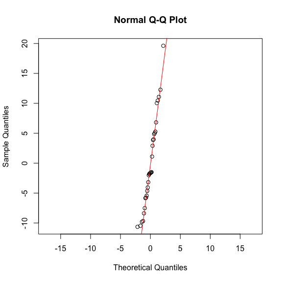

```r
qqnorm(resid(fitmodel2), asp=1); qqline(resid(fitmodel2), col="red")
```

Based on the figure depicted above we can conclude that the model meets the assumption of normality as all points are centered around the line depicted normality.

**-** Homoscedasticity and Linearity

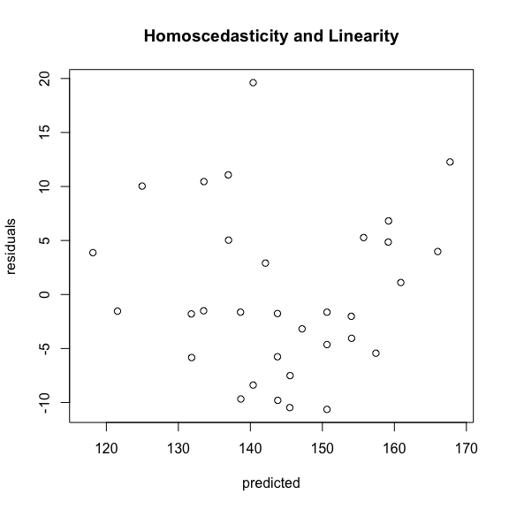

```r
plot(predict(fitmodel2), resid(fitmodel2), main = "Homoscedasticity and Linearity", ylab = "residuals", xlab="predicted", asp=1.5)
```

While the model shows no systematic correlation between the predicted values and the residuals, indicating no heteroscedasticity problem, the assumption of linearity does not appear to be meet as all points are relatively randomly scatter around the graph.

**-** Independence of errors

[figure not shown]

```r
plot(data2$bmi, resid(fitmodel2),  xlab = "age", main = "Independent errors (age)", ylab = "errors")
```

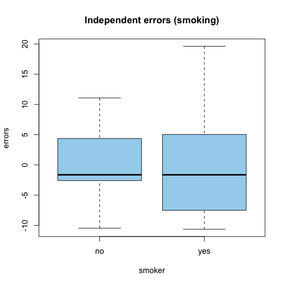

```r
plot(data2$smk, resid(fitmodel2),  xlab = "smoker", main = "Independent errors (smoking)", ylab = "errors", col="lightskyblue2")
```

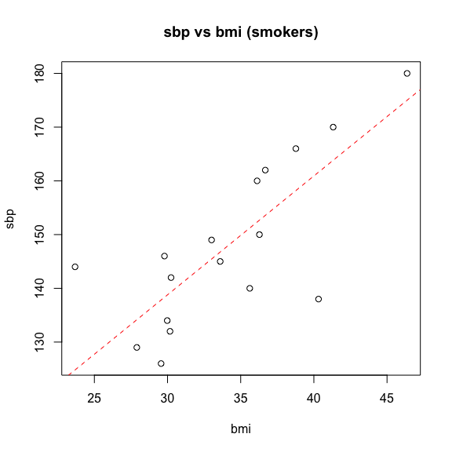

```r
subSmkBmi <- subset(data2, data2$smk=="yes")
subNoSmkBmi <- subset(data2, data2$smk=="no")
plot(subSmkBmi$bmi, subSmkBmi$sbp, ylab="sbp", xlab ="bmi", main = "sbp vs bmi (smokers)")
abline((fitmodel1$coefficients[1]+fitmodel1$coefficients[2]), (fitmodel1$coefficients[3]), col="red",
       lty="dashed")
```

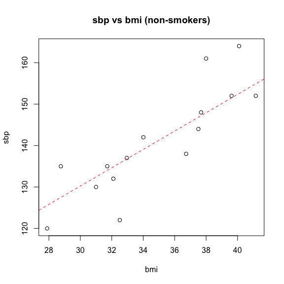

```r
plot(subNoSmkBmi$bmi, subNoSmkBmi$sbp, ylab="sbp", xlab ="bmi", main ="sbp vs bmi (non-smokers)")
abline((fitmodel1$coefficients[1]), (fitmodel1$coefficients[3]), col="red",
       lty="dashed")
```

**d)** Combine all the predictors in a multiple regression. Use a step-wise regression approach. (Compare model fit, inspect assumptions and interpret the model parameters of the best-fitting model)

```r
library(MASS)
fitmodel2 <- lm(sbp~smk+bmi+age+smk:bmi, data=data2)
step <- stepAIC(fitmodel2, direction="both")
```

```
## Start:  AIC=133.8
## sbp ~ smk + bmi + age + smk:bmi
##
##           Df Sum of Sq    RSS    AIC
## - smk:bmi  1      3.94 1536.1 131.88
## <none>                 1532.2 133.80
## - age      1    709.66 2241.9 143.98
##
## Step:  AIC=131.88
## sbp ~ smk + bmi + age
##
##           Df Sum of Sq    RSS    AIC
## <none>                 1536.1 131.88
## + smk:bmi  1      3.94 1532.2 133.80
## - bmi      1    200.14 1736.3 133.80
## - smk      1    769.23 2305.4 142.87
## - age      1    769.46 2305.6 142.88
```

```r
step$anova
```

```
## Stepwise Model Path
## Analysis of Deviance Table
##
## Initial Model:
## sbp ~ smk + bmi + age + smk:bmi
##
## Final Model:
## sbp ~ smk + bmi + age
##
##
##        Step Df Deviance Resid. Df Resid. Dev      AIC
## 1                              27   1532.205 133.7993
## 2 - smk:bmi  1 3.937867        28   1536.143 131.8814
```

## Assignment 3 (Logistic Regression and Hypothesis Tests)

In the file mi.csv we have data of a patient-control study regarding the relationship between mi (myocardial infarction) and many predictors.

```r
dataMi <- read.table("/Users/apple/Downloads/mi.csv", header=TRUE, sep=";",dec=".")
knitr::kable(head(dataMi))
```

| mi | smoking | alcohol | active | sex | profession | bmi | sys | dias |
| --- | --- | --- | --- | --- | --- | --- | --- | --- |
| 1 | 1 | 0 | 0 | 1 | 1 | 24.706 | 130 | 80 |
| 1 | 1 | 0 | 0 | 1 | 2 | 25.106 | 160 | 100 |
| 1 | 1 | 0 | 1 | 1 | 2 | 26.392 | 135 | 80 |
| 1 | 0 | 0 | 0 | 1 | 1 | 24.849 | 120 | 90 |
| 1 | 0 | 1 | 1 | 1 | 1 | 24.251 | 140 | 85 |
| 1 | 0 | 0 | 0 | 1 | 3 | 21.975 | 120 | 80 |

```r
dataScul <- read.table("/Users/apple/Downloads/sculptures.csv", header=TRUE, sep=";",dec=".")
knitr::kable(head(dataScul))
```

| height | weight | sculptor |
| --- | --- | --- |
| 1.810 | 3.906 | Bernini |
| 2.162 | 4.229 | Bernini |
| 2.516 | 4.073 | Bernini |
| 1.936 | 3.664 | Bernini |
| 2.468 | 4.715 | Bernini |
| 2.299 | 3.925 | Bernini |

```r
dataVer <- read.table("/Users/apple/Downloads/veritatis.csv", header=TRUE, sep=";", dec=".")
knitr::kable(head(dataVer))
```

| A | E | I | O | U |
| --- | --- | --- | --- | --- |
| 41 | 26 | 20 | 31 | 15 |
| 37 | 29 | 19 | 43 | 6 |
| 32 | 32 | 11 | 34 | 16 |
| 38 | 16 | 23 | 42 | 16 |
| 33 | 28 | 27 | 27 | 14 |
| 38 | 24 | 23 | 38 | 18 |

**a)** Investigate the association between smoking (variable smoking, 1 = yes, 0 = no) and the event of an infarction using a chi-square test. First display the data on a 2x2 table and then perform the test.

```r
subG <- subset(dataMi, mi>=0, c(1,2))
table <- table(Infarction=subG$mi, Smoking=subG$smoking)
table
```

```
##           Smoking
## Infarction   0   1
##          0 178  32
##          1 150  60
```

```r
chisq1<-chisq.test(table)
chisq1
```

```
##
##  Pearson's Chi-squared test with Yates' continuity correction
##
## data:  table
## X-squared = 10.146, df = 1, p-value = 0.001446
```

As the p-value 0.001446 is smaller than the .05 significance level, we reject the null hypothesis that the smoking habit is independent of the occurrence of myocardial infarctions. We can conclude that there is a relation between smoking and the occurrence of a myocardial infarction.

**b)** Using a logistic regression model, estimate the Odds ratio for NOT having an infarction for smokers compared to non-smokers (if necessary, recode the variables).

```r
summary(glm(mi~smoking, data=subG, family=binomial))
```

```
##
## Call:
## glm(formula = mi ~ smoking, family = binomial, data = subG)
##
## Deviance Residuals:
##      Min        1Q    Median        3Q       Max
## -1.45331  -1.10565  -0.09052   1.25090   1.25090
##
## Coefficients:
##             Estimate Std. Error z value Pr(>|z|)
## (Intercept)  -0.1711     0.1108  -1.544  0.12255
## smoking       0.7998     0.2454   3.260  0.00112 **
## ---
## Signif. codes:  0 '***' 0.001 '**' 0.01 '*' 0.05 '.' 0.1 ' ' 1
##
## (Dispersion parameter for binomial family taken to be 1)
##
##     Null deviance: 582.24  on 419  degrees of freedom
## Residual deviance: 571.19  on 418  degrees of freedom
## AIC: 575.19
##
## Number of Fisher Scoring iterations: 4
```

```r
1/exp(0.7998)
```

```
## [1] 0.4494188
```

Result. The Odds ratio for NOT having an infarction for smokers compared to non-smokers is 0.4494188. Therefore we can conclude that smokers have a higher probability of having an infarction than non-smokers do.

**c)** Investigate the association between the continuous variable BMI (body mass index) and the event of an infarction using a logistic regression model. Is the relationship between BMI and MI significant?

```r
summary1 <- summary(glm(mi~bmi, data=dataMi, family=binomial))
summary1
```

```
##
## Call:
## glm(formula = mi ~ bmi, family = binomial, data = dataMi)
##
## Deviance Residuals:
##     Min       1Q   Median       3Q      Max
## -1.6262  -1.1672  -0.1718   1.1793   1.2107
##
## Coefficients:
##             Estimate Std. Error z value Pr(>|z|)
## (Intercept) -0.33767    0.32610  -1.035     0.30
## bmi          0.01364    0.01263   1.080     0.28
##
## (Dispersion parameter for binomial family taken to be 1)
##
##     Null deviance: 582.24  on 419  degrees of freedom
## Residual deviance: 580.94  on 418  degrees of freedom
##   (359 observations deleted due to missingness)
## AIC: 584.94
##
## Number of Fisher Scoring iterations: 4
```

As the p-value of the bmi variable are higher than 0.05, it is statistically insignificant in the logistic regression model. We can conclude that the bmi variable does not significantly affect the probability of having an infarction.

# Assignment 4 (Classifiers)

In the file sculptures.csv information over 100 sculptures is collected (height in meters and weight, in hundreds of kilograms and sculptor = Bernini or Other). You want to build a classifier that tells between statues made by Bernini (that constitute around the 25% of the total number of statues to classify) and statues made by other artists.

**a)** Build two classifiers (C1 and C2), assuming respectively equality and inequality of the covariance matrices in the two populations (Bernini sculptures and non-Bernini sculptures).

```r
  library(MASS)
  c1 <- lda(sculptor~height+weight, data=dataScul)
  #quadratic
  c2 <- qda(sculptor~height+weight, data=dataScul, prior=c(.25, .75))
```

The first classifier (c1) assumes equality, while the second classifier (c2) assumes inequality.

**b)** Calculate the APER of the two classifiers, comment the results.

```r
#classifier 1
  predict(c1)$class
```

```
##   [1] Bernini Bernini Bernini Bernini Bernini Bernini Bernini Bernini
##   [9] Other   Bernini Bernini Bernini Bernini Bernini Bernini Bernini
##  [17] Bernini Bernini Bernini Bernini Other   Bernini Bernini Other
##  [25] Bernini Bernini Bernini Bernini Bernini Bernini Bernini Bernini
##  [33] Bernini Other   Bernini Other   Other   Bernini Bernini Other
##  [41] Bernini Bernini Other   Bernini Other   Bernini Bernini Other
##  [49] Other   Bernini Bernini Bernini Other   Bernini Bernini Bernini
##  [57] Other   Other   Other   Bernini Other   Other   Bernini Other
##  [65] Bernini Other   Other   Bernini Other   Bernini Other   Other
##  [73] Other   Other   Bernini Bernini Other   Other   Bernini Other
##  [81] Bernini Other   Other   Bernini Other   Other   Other   Other
##  [89] Other   Other   Other   Other   Bernini Other   Other   Bernini
##  [97] Other   Bernini Other   Other
## Levels: Bernini Other
```

```r
  table1 <- table(true = dataScul$sculptor, predicted =predict(c1)$class)
  knitr::kable(table1)
```

|  | Bernini | Other |
| --- | --- | --- |
| Bernini | 39 | 11 |
| Other | 18 | 32 |

```r
# APER = incorrect classifications / total observations
  (18+11)/(100)
```

```
## [1] 0.29
```

```r
#classifier 2
  predict(c2)$class
```

```
##   [1] Bernini Bernini Bernini Other   Bernini Bernini Bernini Bernini
##   [9] Other   Other   Other   Bernini Bernini Bernini Bernini Bernini
##  [17] Bernini Bernini Bernini Bernini Other   Bernini Bernini Other
##  [25] Bernini Bernini Bernini Bernini Bernini Bernini Other   Bernini
##  [33] Other   Other   Bernini Other   Other   Bernini Bernini Other
##  [41] Bernini Other   Other   Bernini Other   Other   Bernini Bernini
##  [49] Other   Other   Bernini Bernini Other   Other   Bernini Other
##  [57] Other   Other   Other   Other   Other   Other   Other   Other
##  [65] Other   Other   Other   Other   Other   Other   Other   Other
##  [73] Other   Other   Bernini Other   Other   Other   Other   Other
##  [81] Other   Other   Other   Other   Other   Other   Other   Other
##  [89] Other   Other   Other   Other   Other   Other   Other   Other
##  [97] Other   Bernini Other   Other
## Levels: Bernini Other
```

```r
  table2 <-table(true= dataScul$sculptor, predicted = predict(c2)$class)
  knitr::kable(table2)
```

|  | Bernini | Other |
| --- | --- | --- |
| Bernini | 32 | 18 |
| Other | 5 | 45 |

```r
# APER = incorrect classifications / total observations
  (18+5)/100
```

```
## [1] 0.23
```

APER for classifier #1: 0.29 APER for classifier #2: 0.23 We can conclude that classifier #2 (c2) is better than classifier 1(c1). The second classifier had a lower incorrect classification ratio (APER) the the first one.

**c)** A new statue is donated to the museum, and it is 2 meters tall and weighs 4 hundreds kilograms. How will the two classifiers classify the new sculpture?

```r
  new.data <- cbind(2,4)
  colnames(new.data) <- c("height", "weight")
  new.data <- as.data.frame(new.data)
  predict(c1, newdata=new.data)
```

```
## $class
## [1] Bernini
## Levels: Bernini Other
##
## $posterior
##     Bernini     Other
## 1 0.5706306 0.4293694
##
## $x
##          LD1
## 1 -0.3206337
```

```r
  predict(c2, newdata = new.data)
```

```
## $class
## [1] Bernini
## Levels: Bernini Other
##
## $posterior
##     Bernini     Other
## 1 0.6162577 0.3837423
```

Classifier #1 will classify the new statue,with a 57.06% probability, as the work of Bernini. Classifier #2 will classify the new statue,with a 61.63% probability, as the work of Bernini.

# Assignment 5 (Clusters)

The veritatis diagram is a mysterious book attributed to Galileo. A famous historian thinks that in some pages of the diagram a secret code is hidden. According to the historian, the pages that contain traces of this code are characterized by an anomalous frequency of certain letters of the alphabet. In the file veritatis.csv the frequencies of each vowel of the Latin alphabet (A,E,I,O,U) are collected for all the 132 pages of the book.

**a)** ) Identify two clusters of pages, using a hierarchical clustering method (Manhattan distance, average linkage).

```r
dist1 <- dist(dataVer, method ="manhattan")
cluster1 <- hclust(dist1, method="average")
 names(cluster1)
```

```
## [1] "merge"       "height"      "order"       "labels"      "method"
## [6] "call"        "dist.method"
```

One of the clusters has 125 pages and the other one has 7 pages. We can conclude that the cluster with 7 pages is the one that contains the mysterious pages.

**b)** Plot the dendrogram of the method, how many suspicious pages did the method identify? At what distance did you cut the dendrogram in order to select two groups?

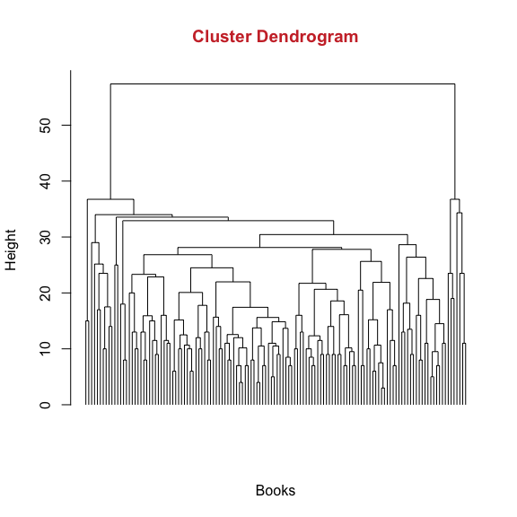

```r
 plot(cluster1, h=-0.1, labels=FALSE, xlab = "Books", col.main="brown3", ann=FALSE)
  title(xlab = "Books", main="Cluster Dendrogram", col.main="brown3", ylab="Height")
```

```r
 groups<-  cutree(cluster1, h=37)
```

One of the clusters has 125 pages and the other one has 7 pages. The distance to cut the dendrogram in order to select two groups is 37.

**c)** Report the average frequency per each vowel, for the two groups that you just clustered.

```r
subset.1 <- subset(dataVer, groups==1)
subset.2 <- subset(dataVer, groups==2)
colMeans(subset.1)
```

```
##      A      E      I      O      U
## 35.336 24.656 19.624 35.720 15.184
```

```r
colMeans(subset.2)
```

```
##        A        E        I        O        U
## 54.28571 26.85714 18.42857 54.28571 16.42857
```

The second cluster, that contains the books with mysterious pages, tend to report a higher average frequency per vowel for the letters: A and O. We can conclude that the vowels A and O are the ones that could have more weight in classifying the mysterious pages.